# STAT5421 HW3

Ruwiada Al Harrasi

2023-11-03

## 3.1

# a

```r
set.seed(5421)
library(CatDataAnalysis)
data(table_4.3)
names(table_4.3)
```

```
## [1] "color"  "spine"  "width"  "satell" "weight" "y"
```

```r
sapply(table_4.3, class)
```

```
##     color     spine     width    satell    weight         y
## "integer" "integer" "numeric" "integer" "integer" "integer"
```

```r
table_4.3$color= as.factor(table_4.3$color)
table_4.3$spine= as.factor(table_4.3$spine)
sapply(table_4.3, class)
```

```
##     color     spine     width    satell    weight         y
##  "factor"  "factor" "numeric" "integer" "integer" "integer"
```

```r
set.seed(5421)
#Test whether any of the terms in the model can be dropped. use any one of Wald, Wilks, Rao for all the tests, your choice. (Do not do more than one of these. Pick one and use it.) Report the P-value for each test. What model do these tests suggest we use?
gout <- glm(satell ~width+weight+color+spine, poisson, data= table_4.3)
gout3=drop1(gout, test = "LRT")
summary(gout)
```

```
##
## Call:
## glm(formula = satell ~ width + weight + color + spine, family = poisson,
##     data = table_4.3)
##
## Coefficients:
##               Estimate Std. Error z value Pr(>|z|)
## (Intercept) -0.3618003  0.9665506  -0.374  0.70817
## width        0.0167487  0.0489197   0.342  0.73207
## weight       0.0004965  0.0001663   2.986  0.00283 **
## color3      -0.2648512  0.1681107  -1.575  0.11515
## color4      -0.5137051  0.1953624  -2.629  0.00855 **
## color5      -0.5308601  0.2269157  -2.339  0.01931 *
## spine2      -0.1503718  0.2135754  -0.704  0.48139
## spine3       0.0872826  0.1199287   0.728  0.46674
## ---
## Signif. codes:  0 '***' 0.001 '**' 0.01 '*' 0.05 '.' 0.1 ' ' 1
##
## (Dispersion parameter for poisson family taken to be 1)
##
##     Null deviance: 632.79  on 172  degrees of freedom
## Residual deviance: 549.59  on 165  degrees of freedom
## AIC: 920.88
##
## Number of Fisher Scoring iterations: 6
```

```r
#Do a Poisson regression of satell
gout1 <- glm(satell ~weight+color , family = poisson(link = "log") , data= table_4.3)
summary(gout1)
```

```
##
## Call:
## glm(formula = satell ~ weight + color, family = poisson(link = "log"),
##     data = table_4.3)
##
## Coefficients:
##               Estimate Std. Error z value Pr(>|z|)
## (Intercept) -4.978e-02  2.331e-01  -0.214   0.8309
## weight       5.462e-04  6.811e-05   8.019 1.07e-15 ***
## color3      -2.051e-01  1.537e-01  -1.334   0.1821
## color4      -4.498e-01  1.757e-01  -2.560   0.0105 *
## color5      -4.520e-01  2.084e-01  -2.169   0.0301 *
## ---
## Signif. codes:  0 '***' 0.001 '**' 0.01 '*' 0.05 '.' 0.1 ' ' 1
##
## (Dispersion parameter for poisson family taken to be 1)
##
##     Null deviance: 632.79  on 172  degrees of freedom
## Residual deviance: 551.80  on 168  degrees of freedom
## AIC: 917.1
##
## Number of Fisher Scoring iterations: 6
```

# b

```r
set.seed(5421)
anova(gout, gout1, test = "LRT")
```

```
## Analysis of Deviance Table
##
## Model 1: satell ~ width + weight + color + spine
## Model 2: satell ~ weight + color
##   Resid. Df Resid. Dev Df Deviance Pr(>Chi)
## 1       165     549.59
## 2       168     551.80 -3  -2.2193   0.5281
```

### 3.2

```r
library(MCM)
library(KernSmooth)
```

# a

```r
set.seed(5421)
gout1=glm(satell ~ 0+ weight+color , family = poisson , data= table_4.3, x=T)
modmat <- gout1$x
response <- gout1$y
summary(gout1)
```

```
##
## Call:
## glm(formula = satell ~ 0 + weight + color, family = poisson,
##     data = table_4.3, x = T)
##
## Coefficients:
##          Estimate Std. Error z value Pr(>|z|)
## weight  5.462e-04  6.811e-05   8.019 1.07e-15 ***
## color2 -4.978e-02  2.331e-01  -0.214   0.8309
## color3 -2.549e-01  1.974e-01  -1.291   0.1967
## color4 -4.996e-01  1.959e-01  -2.551   0.0108 *
## color5 -5.018e-01  2.156e-01  -2.328   0.0199 *
## ---
## Signif. codes:  0 '***' 0.001 '**' 0.01 '*' 0.05 '.' 0.1 ' ' 1
##
## (Dispersion parameter for poisson family taken to be 1)
##
##     Null deviance: 1050.8  on 173  degrees of freedom
## Residual deviance:  551.8  on 168  degrees of freedom
## AIC: 917.1
##
## Number of Fisher Scoring iterations: 6
```

```r
set.seed(5421)
library("mcmc")
library("KernSmooth")
y <- mean(gout1$y)
logl <- function(beta) {
logll= (sum(y * beta - exp(beta)))
 return(logll)
 }

# Define log unnormalized prior function for Poisson regression
log.unnormalized.prior <- function(beta) {
  stopifnot(is.numeric(beta))
  stopifnot(is.finite(beta))
  stopifnot(length(beta) == ncol(modmat))
  log_prior <- (sum((0.5 * beta)) - sum(0.5 * exp(beta)))
  return(log_prior)
}

log.unnormalized.posterior = function(beta) logl(beta)+ log.unnormalized.prior(beta)
```

```r
set.seed(5421)
# Run Metropolis-Hastings sampling
mout <- metrop(log.unnormalized.posterior, rep(0, ncol(modmat)),
    nbatch = 10000000,blen = 1)
mout$accept
```

```
## [1] 0.1028983
```

```r
mout$time
```

```
##    user  system elapsed
##  52.244   0.356  52.934
```

```r
colnames(mout$batch) <- names(gout1$coefficients)
foo <- as.ts(mout$batch)
colMeans(mout$batch)
```

```
##    weight    color2    color3    color4    color5
## 0.6707019 0.6694187 0.6700727 0.6717831 0.6686726
```

```r
apply(foo, 2, sd) / sqrt(mout$nbatch)
```

```
##       weight       color2       color3       color4       color5
## 0.0001839674 0.0001840900 0.0001840119 0.0001845004 0.0001840258
```

```r
set.seed(5421)
foo <- sqrt(diag(var(mout$batch)))
mout <- metrop(mout, scale = foo)
mout$accept
```

```
## [1] 0.2946381
```

```r
mout$time
```

```
##    user  system elapsed
##  53.144   0.361  53.851
```

```r
colnames(mout$batch) <- names(gout1$coefficients)
colMeans(mout$batch)
```

```
##    weight    color2    color3    color4    color5
## 0.6702143 0.6708375 0.6706046 0.6712810 0.6708183
```

```r
foo <- as.ts(mout$batch)
apply(foo, 2, sd) / sqrt(mout$nbatch)
```

```
##       weight       color2       color3       color4       color5
## 0.0001844076 0.0001843743 0.0001840115 0.0001841314 0.0001841589
```

# b

```r
set.seed(5421)
foo <- sqrt(diag(var(mout$batch)))
mout <- metrop(mout, scale = foo)
mout$accept
```

```
## [1] 0.294511
```

```r
mout$time
```

```
##    user  system elapsed
##  54.421   0.389  55.154
```

```r
colnames(mout$batch) <- names(gout1$coefficients)
foo <- as.ts(mout$batch)
apply(foo, 2, sd) / sqrt(mout$nbatch)
```

```
##       weight       color2       color3       color4       color5
## 0.0001843295 0.0001842416 0.0001840441 0.0001841466 0.0001842818
```

when we have the scale as sqrt(diag(var(mout$batch))) Monte Carlo standard errors doesn’t change much but the acceptance rate got higher.and it took it longer to run when se is lower.

```r
set.seed(5421)
mout <- metrop(mout, scale=.0002 )
mout$accept
```

```
## [1] 0.9996865
```

```r
t.test(mout$accept.batch)$conf.int
```

```
## [1] 0.9996755 0.9996975
## attr(,"conf.level")
## [1] 0.95
```

```r
colnames(mout$batch) <- names(gout1$coefficients)
colMeans(mout$batch)
```

```
##    weight    color2    color3    color4    color5
## 0.9327524 0.3900697 1.2960184 0.1229682 0.1912028
```

```r
foo <- as.ts(mout$batch)
apply(foo, 2, sd) / sqrt(mout$nbatch)
```

```
##       weight       color2       color3       color4       color5
## 1.453909e-04 5.200283e-05 3.811074e-05 8.931529e-05 6.707420e-05
```

```r
mout$time
```

```
##    user  system elapsed
##  55.001   0.416  55.772
```

When changing the scale to .0002 with a very good acceptance Monte Carlo standard errors to be less than 0.001. with acceptance rate .99 and the running time doesn’t seem to change a lot but it looks higher than using sqrt(diag(var(mout$batch))) as a scaler. and it took it longer to run when se is lower. #c

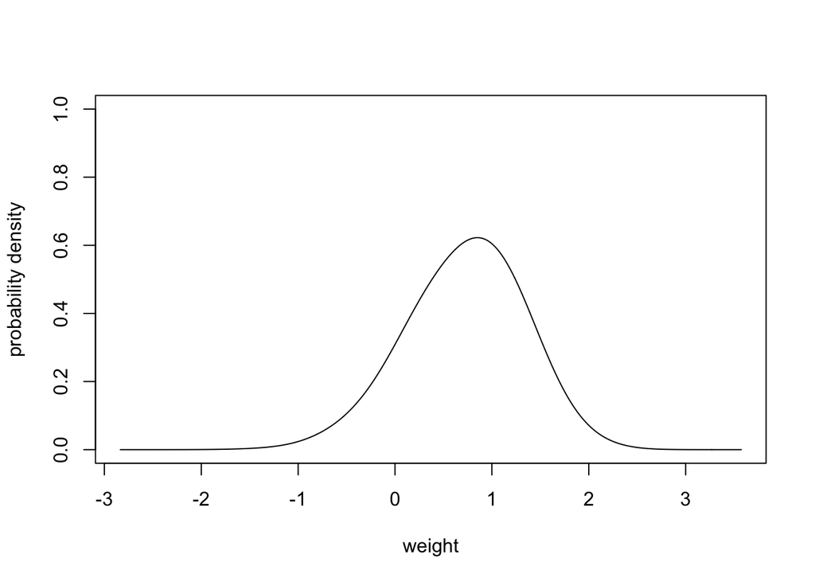

```r
set.seed(5421)
mout <- metrop(log.unnormalized.posterior, rep(0, ncol(modmat)),
    nbatch = 10000, blen = 1)
colnames(mout$batch) <- names(gout1$coefficients)
nu1 <- mout$batch[,"weight"]
idx.sub <- seq(1, length(nu1), by = 500)
nu1.sub <- nu1[idx.sub]
bw <- dpik(nu1.sub)
den <- bkde(nu1, bandwidth = bw)

# Set x-axis limits from -2 to 2
plot(den, type = "l", xlab = "weight", ylab = "probability density",ylim = c(0, 1))
```

We can seee that we have a normal distrebution with a mean close to 1.